# Introduction to CityWaterBalance

Laura Erban

2017-06-15

`CityWaterBalance` provides a reproducible workflow for studying urban water systems. Any system may be modeled with preassembled data, but data for US cities can be gathered via web services using this package and dependencies geoknife and dataRetrieval.

## Install

The latest release of `CityWaterBalance` is available from CRAN. To install:

```r
install.packages("CityWaterBalance")
```

Development version available on Github:

```r
devtools::install_github("USEPA/CityWaterBalance",
                         build_vignettes = TRUE)
```

```r
library("CityWaterBalance")
```

## Usage overview

`CityWaterBalance` is based on a model of the urban water system, shown in the diagram below. This diagram specifies the network of water flows along with a mathematical solution for the changes in water storages (i.e., inflows - outflows) within the system.

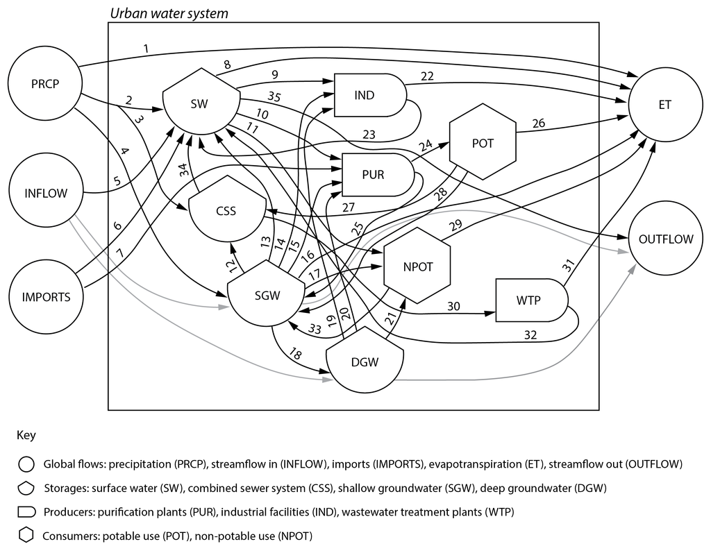

The function, `CityWaterBalance()`, evaluates the urban system model according to the numbered flows described in the table below.

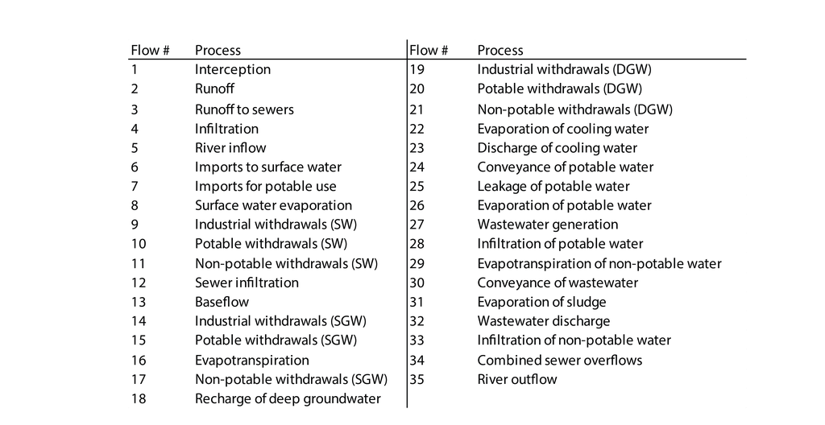

## Usage examples

There are two ways to apply the `CityWaterBalance` workflow.

### Option 1: Input preassembled data

See `CityWaterBalance()` inputs for details on data and parameter inputs. Data must be in self-consistent units. Each row of data must represent the same time period.

The following example is based on the included dataset (`cwb_data`) on flows of water in the Chicago metropolitan area.

```r
# Specify parameters
p <- list("interc" = 0, "et_mult" = 1, "flow_mult" = 1, "open_wat" = 0.02, "run_mult" = 1, "run_css" = 0.35, "bf_mult" = 1, "nonrev" = 0.08,"ind_evap" = 0.012, "wast_gen" = 0.85, "pot_atm" = 0.13, "npot_infilt" = 0.5, "slud_evap" = 0, "leak_css" = 0.05, "dgw" = 0.5,"dgw_rep" = 0.5)

# Run model
m <- CityWaterBalance(cwb_data,p, print=FALSE)
```

Output from the model includes a list of 5 `zoo` series with values at each timestep for: 1) global flows, 2) internal flows, 3) state variables (storages, producers and consumers), 4) internal and 5) global water balances.

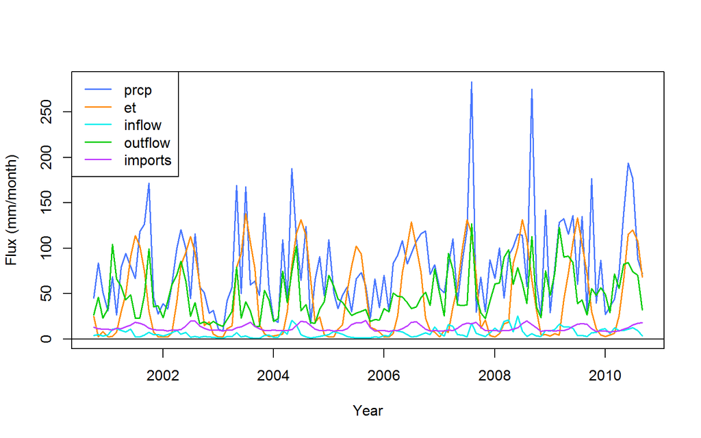

```r
# Visualize output
gf <- m$global_flows
plotWaterBalance(gf, yl = "Flux (mm/month)")
```

### Option 2: Input data gathered from web services

`CityWaterBalance` has other functions that assemble data for the model. At this time, these functions access US-based web services.

#### Specify spatial and temporal boundaries

Define an area of interest (AOI) and upload that geometry to the [USGS Geo Data Portal](https://cida.usgs.gov/gdp/) (GDP). The GDP will give the geometry a name, which may start with ‘upload:’. Here we use a geometry that is already available to the GDP in order to automate the example.

```r
geometry <- 'sample:Counties'
attribute <- 'STATE'
value <- 'RI'
area <- 2707
start <- "2010-01-01"
end <- "2010-12-31"
```

#### Get atmospheric data

```r
latitude <- 41.5801
atm <- getAtmoFlows(start, end, geometry, attribute, value, latitude)
```

#### Get streamflow data

Choose streamgages to evaluate total inflow and outflow for the AOI.  
[NWIS mapper](https://maps.waterdata.usgs.gov/) may be useful here.

```r
ingages <- c("01112500")
outgages <-c("01113895","01114000","01117000","01118500")

inflows <- getStreamflow(start,end,ingages)
outflows<- getStreamflow(start,end,outgages)
```

Look at the streamflow data with the function `plotStreamflow()`. Gaps can be filled using `gapfillStreamflow()`. When time series for all gages are complete, use `combineStreamflow()` to aggegate total in/outflow.

#### Get water use data

Identify the states and counties in your AOI. County is the finest spatial scale for [USGS water use data](https://waterdata.usgs.gov/nwis/wu) served by NWIS.

```r
states <- c("RI")
counties <- list(c("Providence","Kent","Bristol","Newport","Washington"))
wu_raw <- getWaterUse(states,counties,years="ALL")
```

The above retrieves [USGS water use](https://water.usgs.gov/watuse/) data for the specified counties for all available years and withdrawal categories. To reorganize the output for use by `CityWaterBalance()` use:

```r
wu <- combineWaterUse(start,end,wu_raw)
```

#### Get other data

Not all input data is currently available via web services. These inputs (i.e., wastewater effluent, sewer overflows, runoff, baseflow and deep groundwater recharge) must be gathered from other sources and converted to xts objects with the same temporal range and resolution as the other flows. Units must correspond with those specified for inputs to `mergeData()`.

Finally, merge the data into a single xts of fluxes (i.e., flow/AOI) for input to `CityWaterBalance()`.

```r
# combine streamflow among gauges
inflow <- combineStreamflow(inflows, c(1))
outflow <- combineStreamflow(outflows, c(1,1,1,1))
model_data <- mergeData(area,atm,inflow,outflow,wu)
```

### Solve

`CityWaterBalance()` solves for the changes in storage of system components. Acceptable solutions can be determined using ancillary observations (e.g., groundwater levels). Owing to uncertainty in input data, parameters, and ancillary observations of system storages, acceptable solutions will vary within a solution space.

Solutions within this space may be discovered, and the sensitivity of modeled flow explored, with the function `getSolutions()`. `getSolutions()` tests for parameter sets that satisfy criteria for the changes in all system storages. It will continue testing additional parameter sets until the mean flow solution differs by less than a user-specified tolerance (`tol`). Although the `CityWaterBalance()` model runs quickly, running it many times to achieve a stable solution may take quite a while.

The following example shows how to search for model solutions that satisfy a criteria for storage in the combined sewer system again using `cwb_data`. In this dataset, the combined sewer overflow (cso) do not span the complete analysis period. To compensate, the cso flow is set to zero and the acceptable range for the css balance is set to the mean and median of the original data. Other criteria are left at default values. The `tol` is set high so the example will run in a reasonable amount of time.

The boxplot call illustrates one way that results may be visualized.

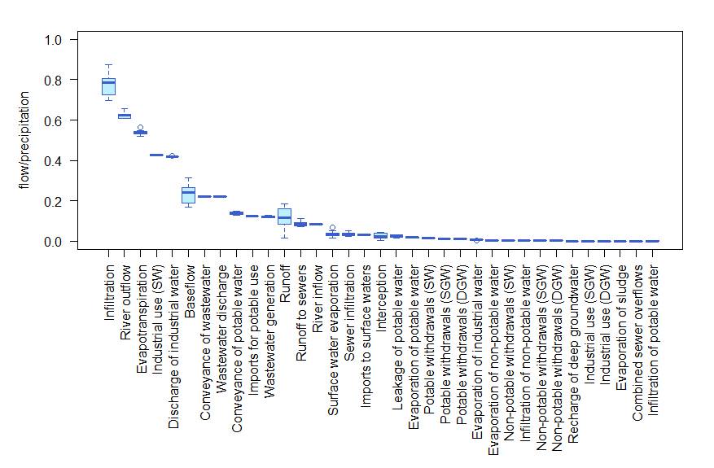

```r
d <- cwb_data
d$cso <- 0

params <- list("interc" = 0, "et_mult" = 1, "flow_mult" = 1, "open_wat" = 0.02, "run_mult" = 1, "run_css" = 0.35, "bf_mult" = 1, "nonrev" = 0.08,"ind_evap" = 0.012, "wast_gen" = 0.85, "pot_atm" = 0.13, "npot_infilt" = 0.5, "slud_evap" = 0, "leak_css" = 0.05, "dgw" = 0.5,"dgw_rep" = 0.5)

low <- median(cwb_data$cso,na.rm=TRUE)*nrow(cwb_data)
high <- mean(cwb_data$cso,na.rm=TRUE)*nrow(cwb_data)
css_crit <- c(low,high)

out <- getSolutions(data = d, p = params, n = 100, tol = 100, css_bal = css_crit)
boxplot(out[,order(colMeans(out),decreasing=TRUE)]/sum(d$prcp),las = 2,
ylab = "flow/precipitation", ylim = c(0,1),col = c("lightblue1"),
border = c("royalblue3"))
```